# EC7025 - SFC

## Example of Transaction Flow Matrix

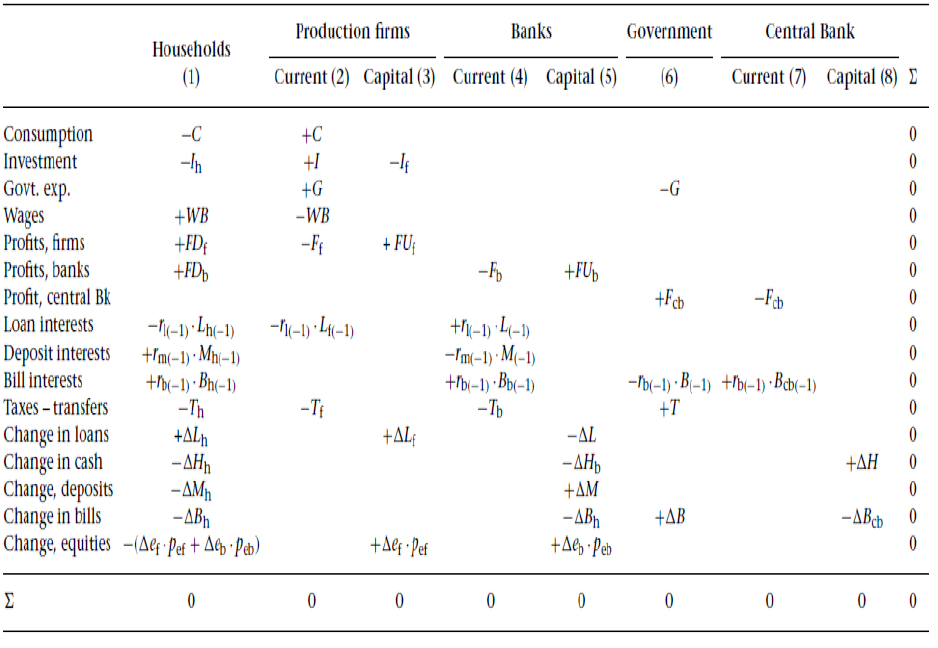

Transaction Flow Matrix, source: G&L 2007

## Transaction flow matrix, part 2

- Once you have identified the first two parts of the transactions flow matrix, you have a complete picture of income sources and expenditures of each sector in your model.
- Naturally, the difference between income and expenditures yields the savings of each sector, which are then allocated to real and financial assets to accumulate wealth.
- The last part of the full flow matrix shows which assets and liabilities these savings/dis-savings have been channeled to.
- In order to ensure that each column adds up to zero, we have to record the changes in assets/liabilities in a non-intuitive way and record changes in assets with a (-) sign and change in liabilities with a (+) sign.
- Therefore, each column now shows

*Income – Expenditures – Change in assets/liabilities =0*

## Full integration matrix

- Once you have written down the transactions flow matrix, you can move to derive the full integration matrix, which simply shows the changes in net worth of your sectors between the beginning of the period and the end of the period.
- In order to do so, you use the bottom part of the transactions flow matrix with opposite signs in order to make sure increases in assets lead to an increase in net worth and increases in liabilities lead to a decrease in net worth. (Do not forget to add change in tangible capital)
- One further consideration is the change in the value of some stocks of assets between the beginning of the period and the end of the period.
- In order to capture this, you will need to add rows for the assets whose values are subject to such change.
- The last row now becomes the net worth of each sector at the end of the period.

## Example of Full Integration Matrix

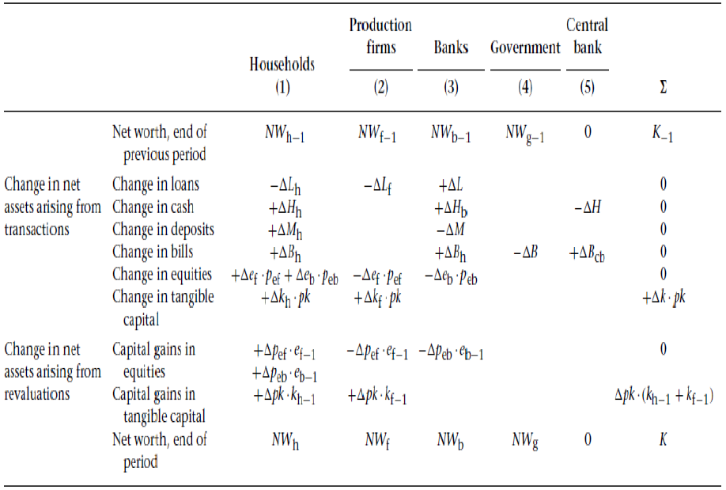

Full Integration Matrix, source: G&L 2007

# Data

## Eurostat

[figure not shown]

Data Search in Eurostat

[figure not shown]

Data Table in Eurostat

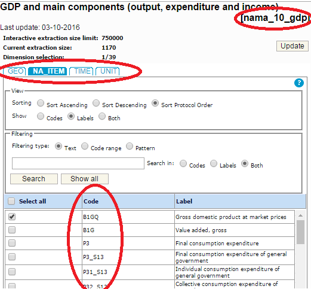

Data Details

## Looking at sectoral Accounts

url: http://ec.europa.eu/eurostat/web/sector-accounts

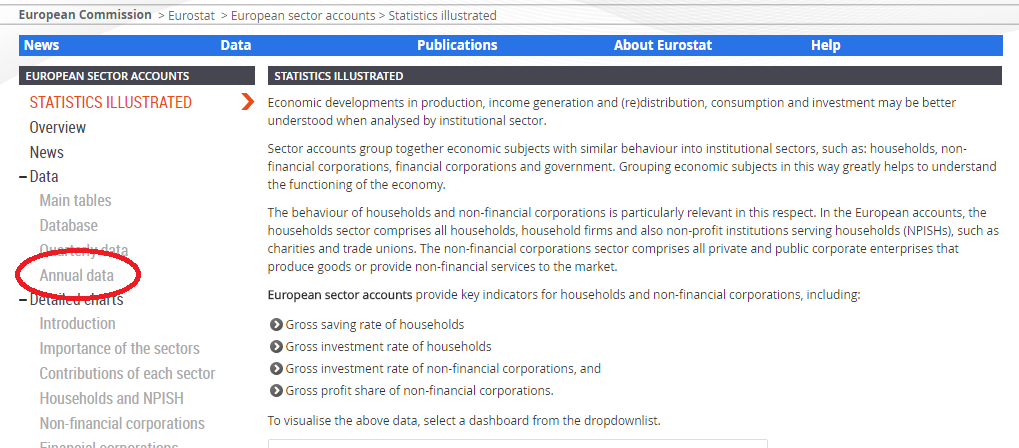

Sectoral Accounts webpage

[figure not shown]

Sectoral Accounts Countries Data

## pdfetch: getting data automatically

- Fetch Economic and Financial Time Series Data from Public Sources
- Package developed by Abiel Reinhart
- We will be using the `pdfetch_EUROSTAT` function

## Example 1: Net lending per sector, UK

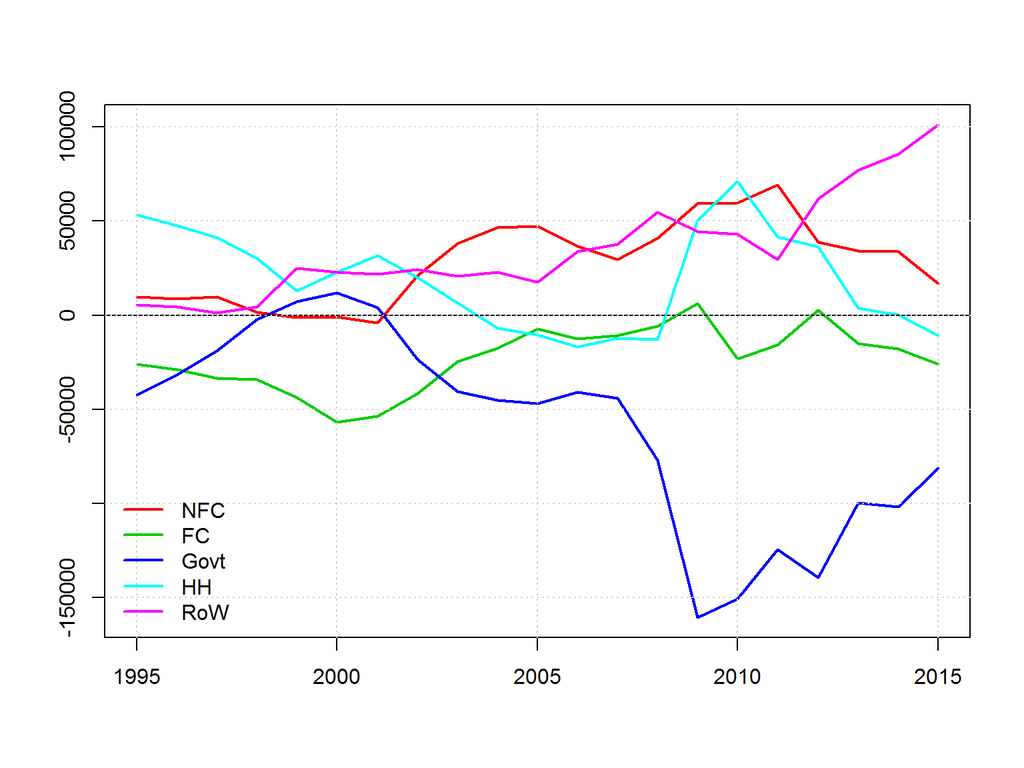

```r
# Specifying the name of the flows of interests
names<-c("B9")
# Downloading the data by specifying the various filters
UKdata_raw = pdfetch_EUROSTAT(flowRef = "nasa_10_nf_tr",
        UNIT="CP_MNAC",NA_ITEM=names, GEO="UK", DIRECT="PAID",
        SECTOR=c("S11","S12","S13","S14_S15","S2"))
# Transforming the obtained data into a data.frame
UKdata<-as.data.frame(UKdata_raw)
# Setting readable names
colnames(UKdata)<-c("NFC","FC","Govt","HH","RoW")

# Matricial plot
matplot(1995:2015,UKdata,lwd=2,type="l",lty=1,
        ylab="",xlab="",col=2:6)
# Adding the horizontal line
abline(h=0,col=1)
# Adding a grid
grid()
# Adding a legend
legend("bottomleft",col=c(2:6),lwd=2,lty=1,legend=c("NFC",
        "FC","Govt","HH","RoW"),bty='n')
```

## Example 2: Household income statement from 2014

```r
# Selecting the flows
names<-c("B5G","D5","D61","D62","D7","D8","B6G","P3","B8G"
            ,"P5G","D9","NP","B9")
# Obtaining the data
EZdata_raw = pdfetch_EUROSTAT("nasa_10_nf_tr",
            UNIT="CP_MNAC",NA_ITEM=names, GEO="EU28",
            SECTOR=c("S14_S15"), TIME="2014")
# Transforming the data into a data.frame
EZdata<-as.data.frame(EZdata_raw)

# Automatic procedure to remove the non-interesting bit
# of the colnames
coln<-colnames(EZdata)
newcoln<-c()
HHdata<-c()
for(i in 1:length(coln)){
  name<-coln[i]
  tname<-strsplit(name,"\\.")[[1]]
  newname<-paste(tname[3:4],collapse=".")
# If the column contains only NA, remove it from dataset
  if(!is.na(EZdata[16,i])){
    newcoln<-c(newcoln,newname)
    HHdata<-c(HHdata,EZdata[16,i])
  }
}

# Creating a new dataset with only values 2014
HHdata<-as.data.frame(t(HHdata))
colnames(HHdata)<-newcoln
# Creating the aggregates
HHdata_1<-as.data.frame(c(HHdata$PAID.B5G,-HHdata$PAID.D5,
            -HHdata$PAID.D61+HHdata$RECV.D61,
            +HHdata$RECV.D62-HHdata$PAID.D62,
            -HHdata$PAID.D7+HHdata$RECV.D7,HHdata$PAID.B6G))
colnames(HHdata_1)<-"Households"
rownames(HHdata_1)<-c("Total Income","Taxes"
        ,"Social Contributions","Social Benefits",
        "Other transfers","Gross Disposable Income")
kable(HHdata_1)
```

|  | Households |
| --- | --- |
| Total Income | 9851688 |
| Taxes | -1442130 |
| Social Contributions | -2425244 |
| Social Benefits | 2635931 |
| Other transfers | 109116 |
| Gross Disposable Income | 8729361 |

```r
HHdata_2<-as.data.frame(c(HHdata$PAID.B6G,-HHdata$PAID.P3,
        -HHdata$PAID.D8+HHdata$RECV.D8,HHdata$PAID.B8G))
colnames(HHdata_2)<-"2014"
rownames(HHdata_2)<-c("Gross Disposable Income",
    "Consumption","Adjustments in Pensions","Gross Savings")
kable(HHdata_2)
```

|  | 2014 |
| --- | --- |
| Gross Disposable Income | 8729361 |
| Consumption | -8012603 |
| Adjustments in Pensions | 201553 |
| Gross Savings | 918310 |

```r
HHdata_3<-as.data.frame(c(HHdata$PAID.B8G,-HHdata$PAID.P5G
        ,-HHdata$PAID.D9+HHdata$RECV.D9,-HHdata$PAID.NP,
        HHdata$PAID.B9))

colnames(HHdata_3)<-"2014"
rownames(HHdata_3)<-c("Gross Savings",
        "Gross Capital Formation","Capital Transfer",
        "Net Non-Produced NF Assets","Net Lending Position")
kable(HHdata_3)
```

|  | 2014 |
| --- | --- |
| Gross Savings | 918310 |
| Gross Capital Formation | -716849 |
| Capital Transfer | 14213 |
| Net Non-Produced NF Assets | 6360 |
| Net Lending Position | 222034 |